# spatstat package

Pei-Rou Lin

2018年2月26日

## spatstat 套件簡介

- 功能 : 一個處理空間分析的套件，主要分析**空間點模式(spatial point patterns)**
- 資料 : 含有點的位置資料，此外可以包含額外資訊(marks)。
  - 適用:

    例如:犯罪地點、便利商店位置等
  - 不適用 :

    相同位置含有不同特性，例如:紀錄每個地方的溫度資料

    不同位置代表同一個東西在不同的時間，例如:每個小時記錄某個鯊魚的位置
- 功能:
  - 生成點模式(point pattern)
  - EDA
  - 分析方法

    樣方分析、核密度估計、判斷是否為完全隨機分布(CRS):G函數F函數等

### spatstat 的基本物件

- ppp:平面上的點(planar point pattern)
- owin:視窗(spatial region (‘observation window’))
- im :畫素影像(pixel image)
- psp:線段 pattern of line segments
- tess:鑲嵌tessellation

```r
library(spatstat)
#data(package="spatstat.data")
#可以查看內建的資料集
```

- example:spatstat內建資料集bei

```r
bei #Tropical rain forest trees
```

```
## Planar point pattern: 3604 points
## window: rectangle = [0, 1000] x [0, 500] metres
```

```r
class(bei)
```

```
## [1] "ppp"
```

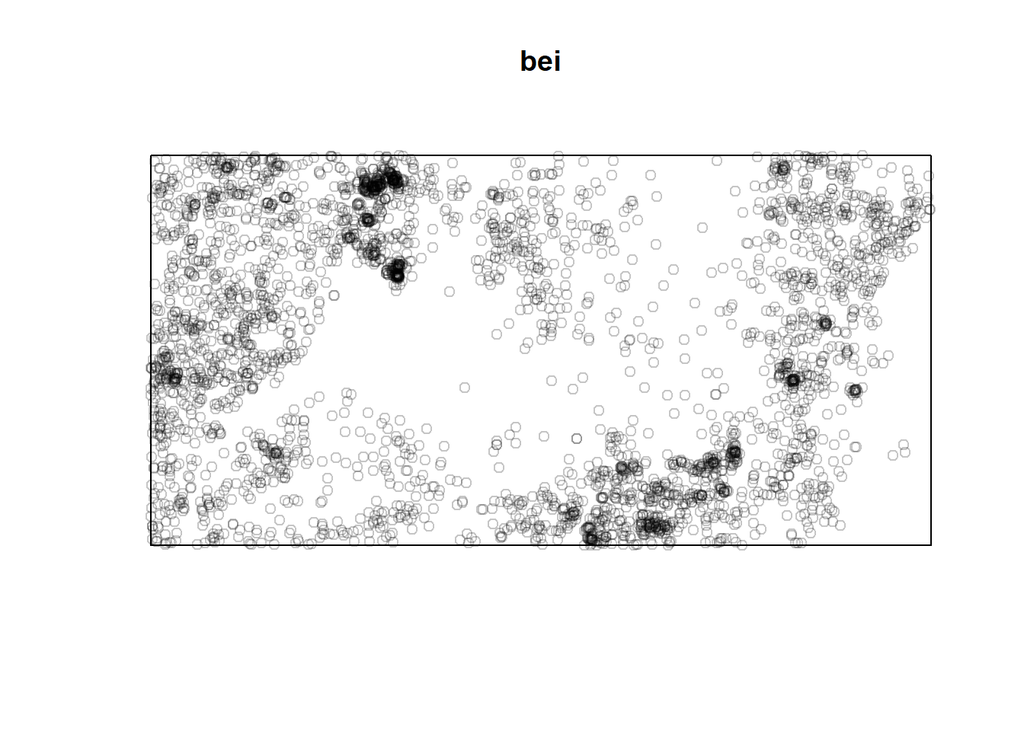

```r
plot(bei)
```

```r
class(bei$window)
```

```
## [1] "owin"
```

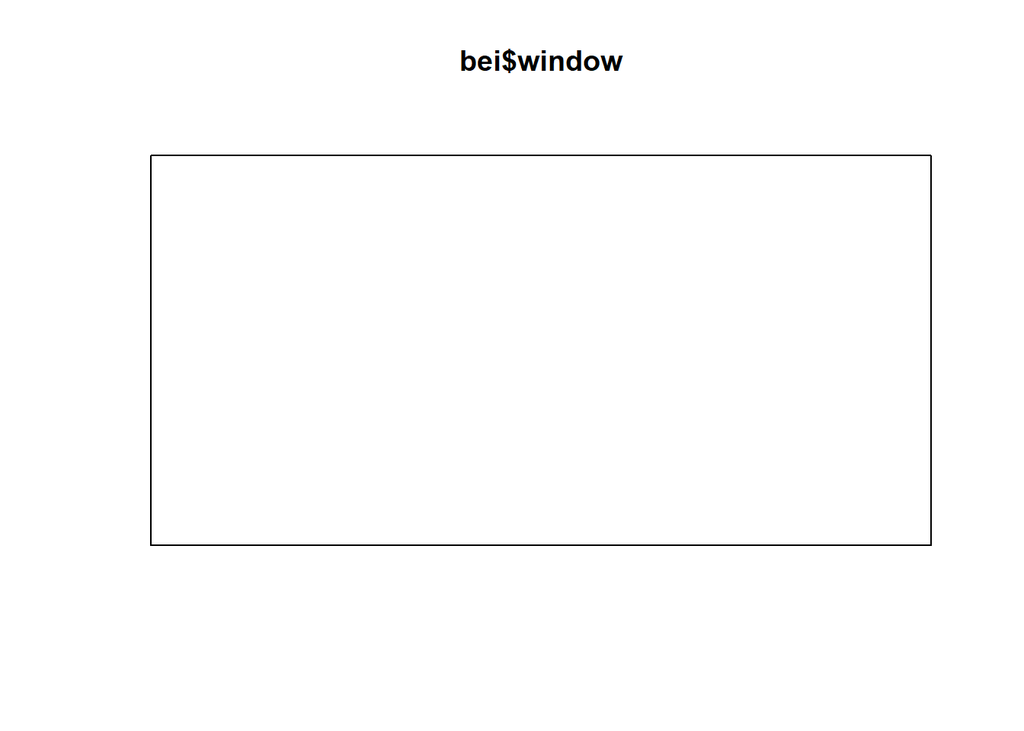

```r
plot(bei$window)
```

```r
class(density(bei))
```

```
## [1] "im"
```

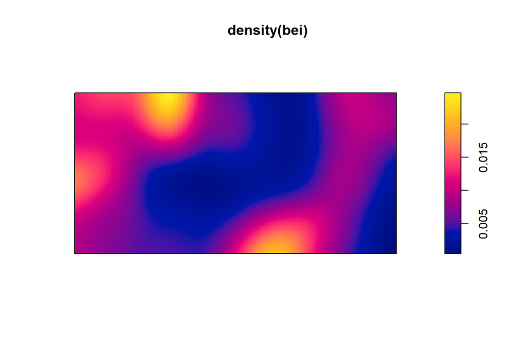

```r
plot(density(bei))
```

```r
ants #紀錄螞蟻巢穴的位置;marks:螞蟻種類Cataglyphis, Messor
```

```
## Marked planar point pattern: 97 points
## Multitype, with levels = Cataglyphis, Messor
## window: polygonal boundary
## enclosing rectangle: [-25, 803] x [-49, 717] units (one unit = 0.5 feet)
```

```r
marks(ants)
```

```
##  [1] Messor      Messor      Messor      Messor      Messor
##  [6] Messor      Messor      Messor      Messor      Messor
## [11] Messor      Messor      Messor      Messor      Messor
## [16] Messor      Messor      Messor      Messor      Messor
## [21] Messor      Messor      Messor      Messor      Messor
## [26] Messor      Messor      Messor      Messor      Messor
## [31] Messor      Messor      Messor      Messor      Messor
## [36] Messor      Messor      Messor      Messor      Messor
## [41] Messor      Messor      Messor      Messor      Messor
## [46] Messor      Messor      Messor      Messor      Messor
## [51] Messor      Messor      Messor      Messor      Messor
## [56] Messor      Messor      Messor      Messor      Messor
## [61] Messor      Messor      Messor      Messor      Messor
## [66] Messor      Messor      Messor      Cataglyphis Cataglyphis
## [71] Cataglyphis Cataglyphis Cataglyphis Cataglyphis Cataglyphis
## [76] Cataglyphis Cataglyphis Cataglyphis Cataglyphis Cataglyphis
## [81] Cataglyphis Cataglyphis Cataglyphis Cataglyphis Cataglyphis
## [86] Cataglyphis Cataglyphis Cataglyphis Cataglyphis Cataglyphis
## [91] Cataglyphis Cataglyphis Cataglyphis Cataglyphis Cataglyphis
## [96] Cataglyphis Cataglyphis
## Levels: Cataglyphis Messor
```

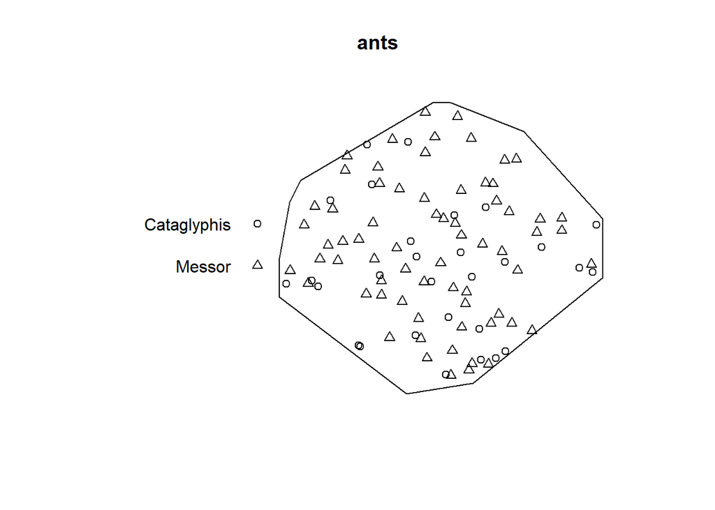

```r
plot(ants)
```

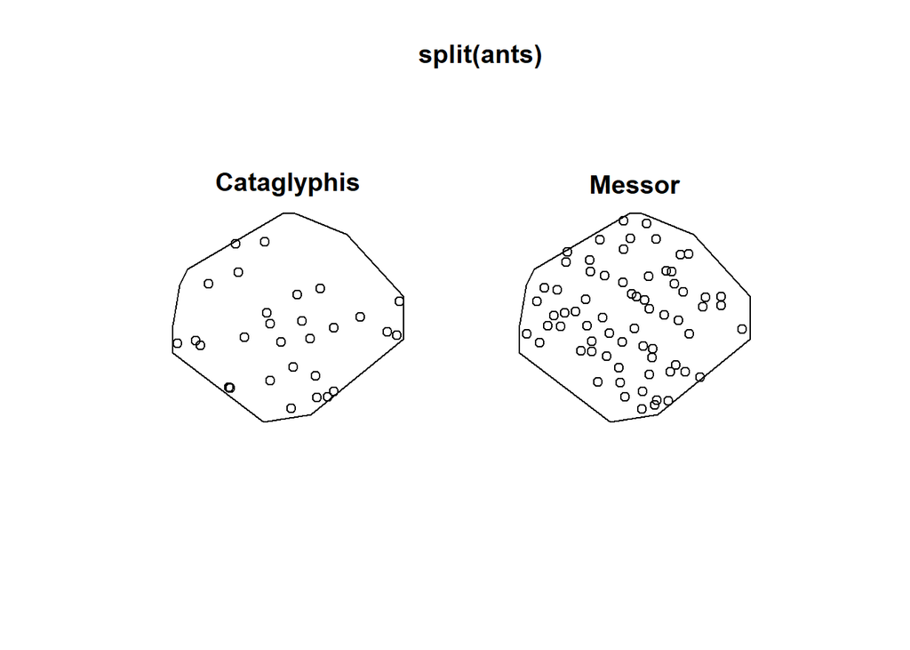

```r
plot(split(ants)) #以marks畫
```

### 生成owin物件

`owin(xrange,yrange,poly,mask)`

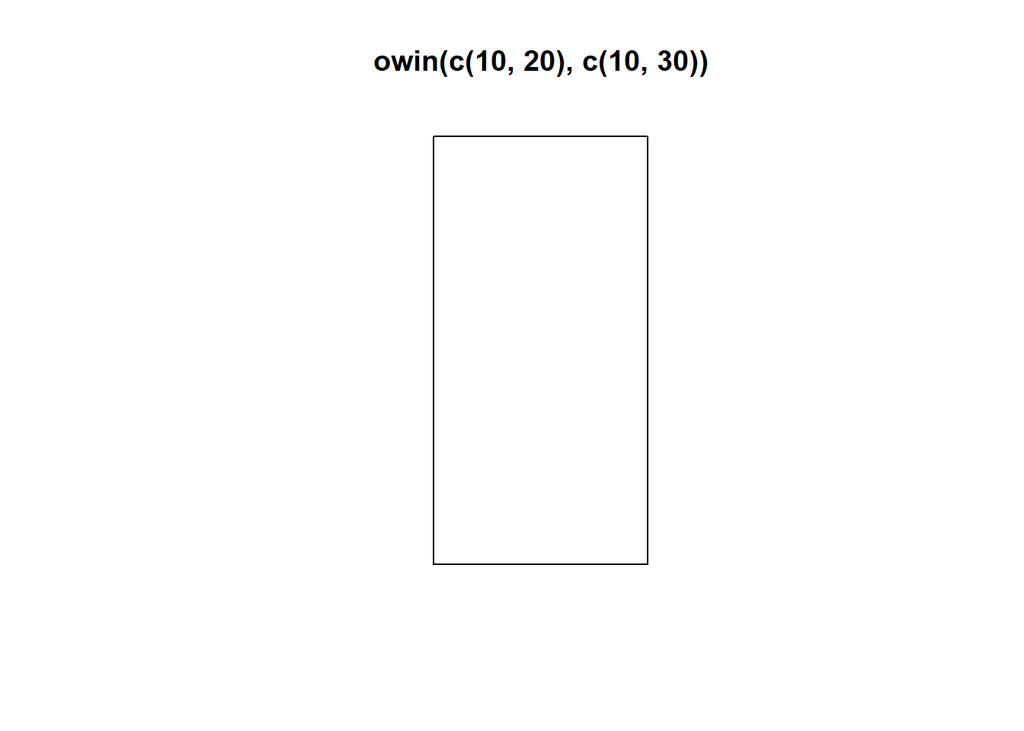

```r
plot(owin(c(10,20), c(10,30))) #矩形
```

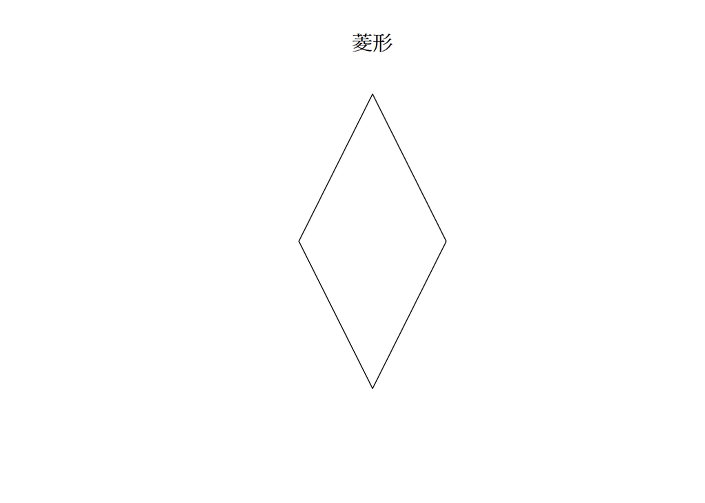

```r
plot(owin(poly=list(x=c(0.5,1,0.5,0),y=c(0,1,2,1))),main="菱形") #菱形
```

[figure not shown]

```r
plot(owin(poly=list(list(x=c(0,1,1,0), y=c(0,0,1,1)),
                        mask=list(x=c(0.6,0.4,0.4,0.6), y=c(0.2,0.2,0.4,0.4)))),main="")#中間有洞
```

#### example:台北市區界資料

```r
library(maptools)
S <- readShapePoly("C:\\Users\\ASUS\\Desktop\\google drive\\workshop\\碩一上\\711設店相關\\data\\1040826_區界\\G97_A_CADIST_P.shp")##S為SpatialPolygonsDataFrame物件
#轉換經緯度 : TWD97(EPSG:3826) -> WGS84(EPSG:4326)
library(rgdal)
proj4string(S) <- CRS("+init=EPSG:3826")
S1 <- spTransform(S, CRS("+init=EPSG:4326"))
W <- as(S1, "owin")#轉成owin
W
```

```
## window: polygonal boundary
## enclosing rectangle: [121.45881, 121.66587] x [24.960318, 25.210191] units
```

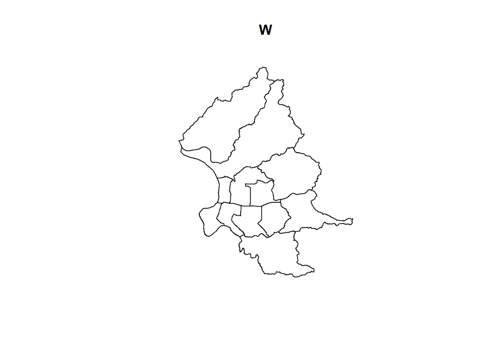

```r
plot(W)
```

### 生成ppp物件

- 需要有**點的位置**和**觀察的範圍** ，如果有額外資訊則記錄在`marks`中
- 觀察的範圍 :

  矩形則`ppp(x, y, xrange, yrange, marks=m)`

  非矩形則`ppp(x, y, window = W, marks=m)`

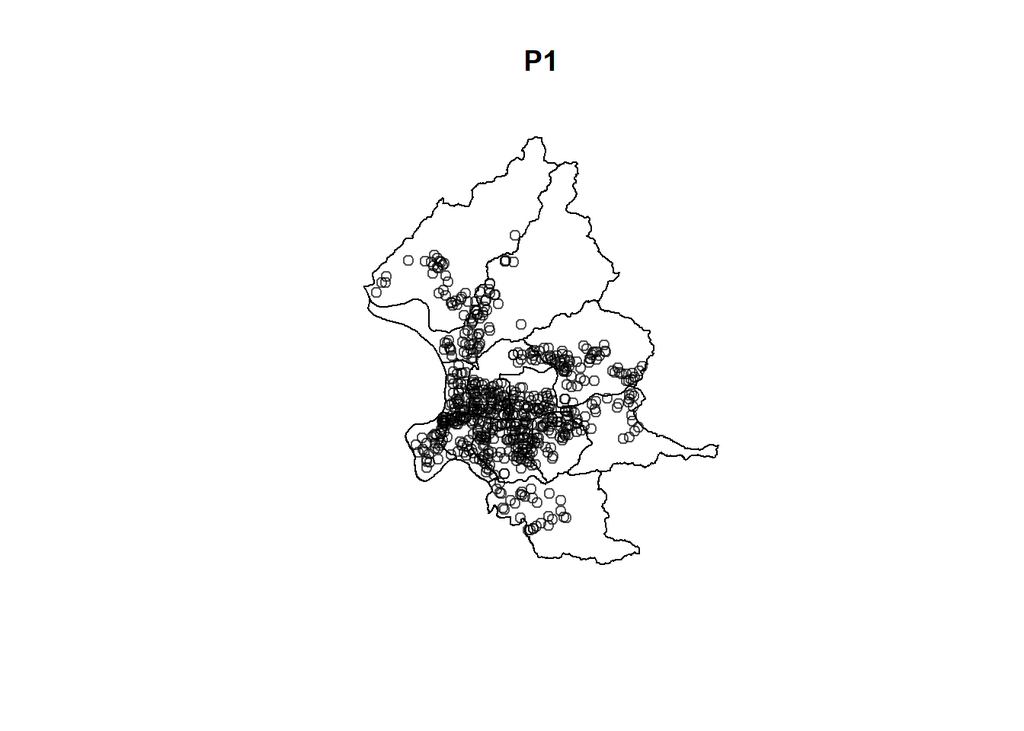

```r
library(maptools)
P<- read.csv("C:\\Users\\ASUS\\Desktop\\google drive\\workshop\\碩一上\\711設店相關\\data\\store.csv")
P1<-ppp(x=P$lon,y=P$lat,W)
plot(P1)
```

### 生成psp物件

`psp(x0,y0, x1, y1, window, marks=NULL)`

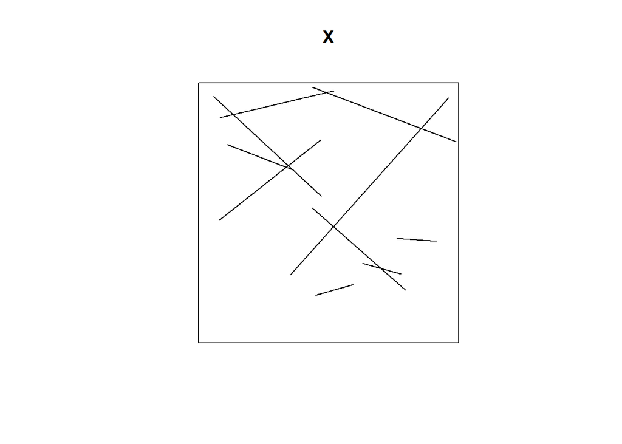

```r
X <- psp(runif(10), runif(10), runif(10), runif(10), window=owin())
plot(X)
```

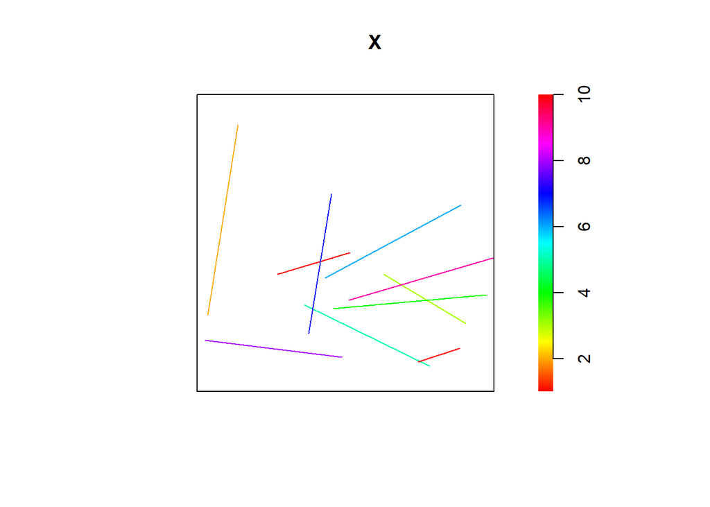

```r
m <- data.frame(A=1:10, B=letters[1:10])
X <- psp(runif(10), runif(10), runif(10), runif(10), window=owin(), marks=m)
plot(X)
```

## 分析點模式

### 空間型態 : 是否為**聚集**、**均勻**、**隨機分布**

例子 :

左為紅衫樹、中為日本黑松、右為細胞中心

可看出紅衫樹有聚集現象，細胞為均勻分布，而日本黑松可能為隨機分布。

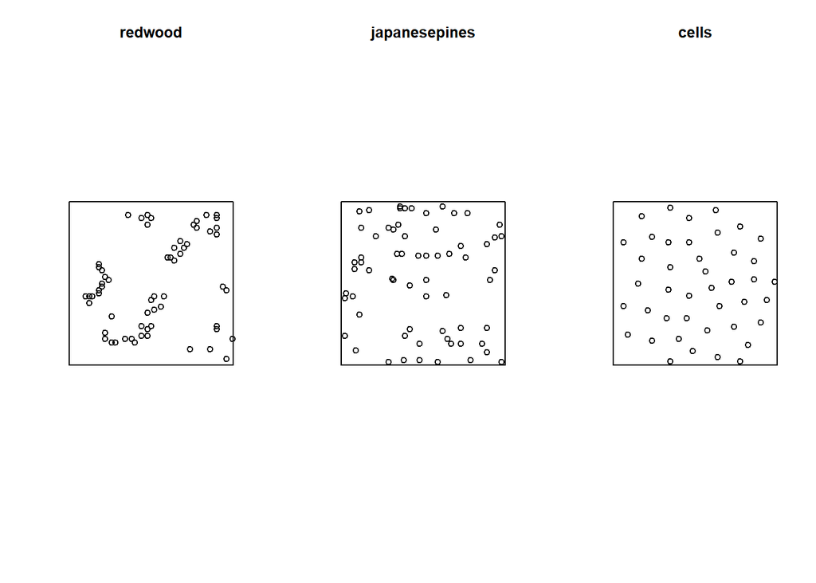

```r
par(mfrow=c(1,3))
plot(redwood)
plot(japanesepines)
plot(cells)
```

```r
summary(cells)
```

```
## Planar point pattern:  42 points
## Average intensity 42 points per square unit
##
## Coordinates are given to 3 decimal places
## i.e. rounded to the nearest multiple of 0.001 units
##
## Window: rectangle = [0, 1] x [0, 1] units
## Window area = 1 square unit
```

### 樣方分析和核密度估計示意圖

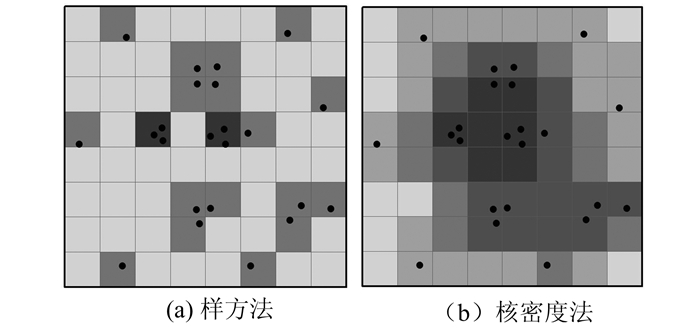

### 樣方分析(quadrat analysis)

`quadratcount(ppp,nx,ny)`:基於**密度**，在圖上分隔數個大小相同的方格，計算每個格子內所包含的點數量。

`quadrat.test(ppp)`:利用卡方檢定是否為**隨機分布**

#### example:spatstat的資料集(bei)

```r
quadratcount(bei)
```

```
##            x
## y           [0,200) [200,400) [400,600) [600,800) [800,1e+03]
##   [400,500]     271       401       100        32         215
##   [300,400)     180       217       104        34         149
##   [200,300)     334         4        26        33         172
##   [100,200)     172        43        26       144          83
##   [0,100)       146        89       234       338          57
```

```r
quadratcount(bei,3,3)
```

```
##            x
## y           [0,333) [333,667) [667,1e+03]
##   [333,500]     945       235         373
##   [167,333)     471        69         274
##   [0,167)       365       498         374
```

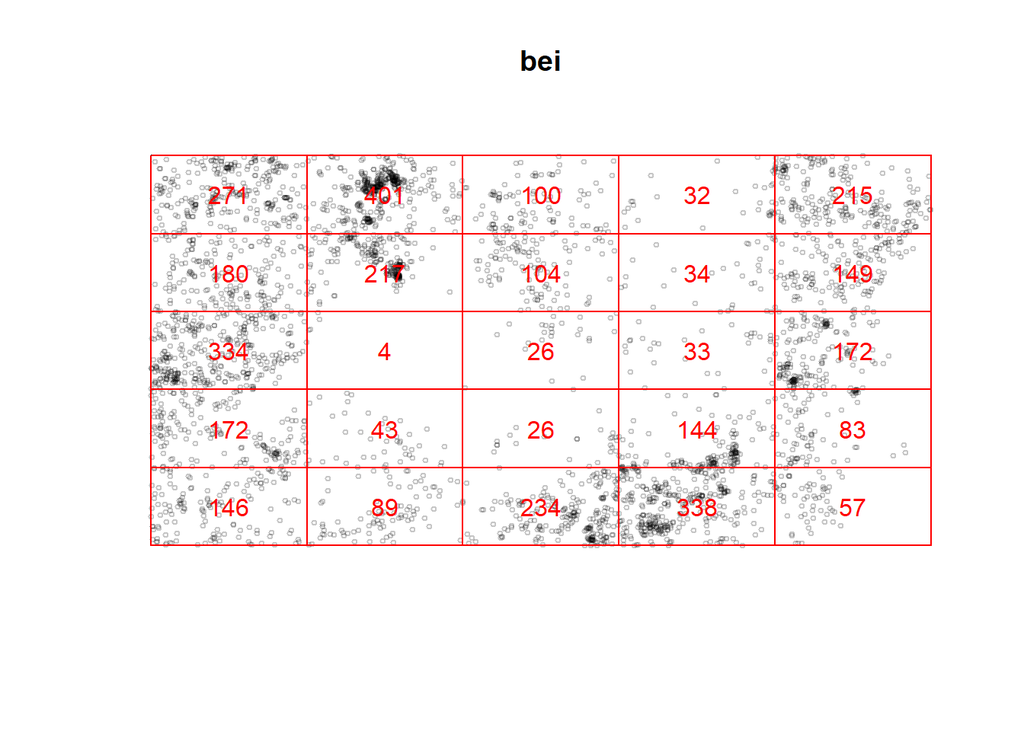

```r
plot(bei,cex=0.5)
plot(quadratcount(bei),add=TRUE,col="red")
```

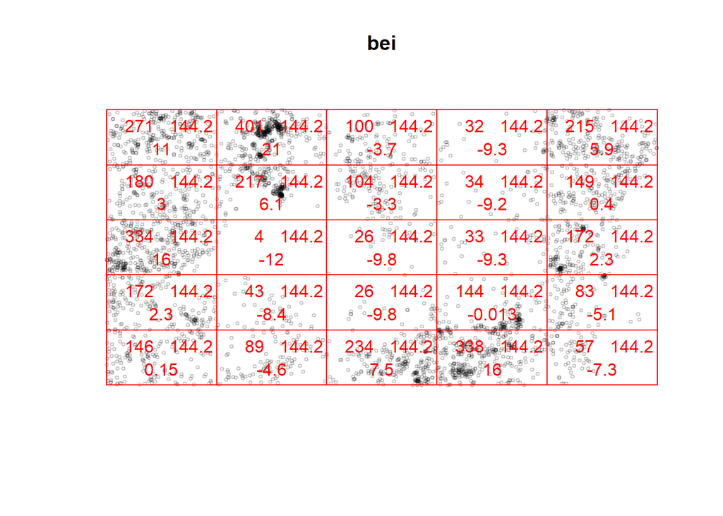

```r
#Ho:點為隨機分布
plot(bei,cex=0.5)
plot(quadrat.test(bei),add=TRUE,col="red") #左上:觀察值、右上:期望值、下方:差值
```

```r
quadrat.test(bei)#p-value 很小，拒絕 Ho
```

```
##
##  Chi-squared test of CSR using quadrat counts
##  Pearson X2 statistic
##
## data:  bei
## X2 = 2009.9, df = 24, p-value < 2.2e-16
## alternative hypothesis: two.sided
##
## Quadrats: 5 by 5 grid of tiles
```

#### example:台北市711分布

```r
quadratcount(P1)
```

```
## tile
## Tile row 1, col 1 Tile row 1, col 2 Tile row 1, col 3 Tile row 1, col 4
##                 0                 0                 0                 0
## Tile row 2, col 1 Tile row 2, col 2 Tile row 2, col 3 Tile row 2, col 4
##                10                33                 5                 0
## Tile row 3, col 1 Tile row 3, col 2 Tile row 3, col 3 Tile row 3, col 4
##                 0                79                47                34
## Tile row 3, col 5 Tile row 4, col 1 Tile row 4, col 2 Tile row 4, col 3
##                 0                13               171               154
## Tile row 4, col 4 Tile row 4, col 5 Tile row 5, col 1 Tile row 5, col 2
##                27                 0                 0                 6
## Tile row 5, col 3 Tile row 5, col 4
##                24                 0
```

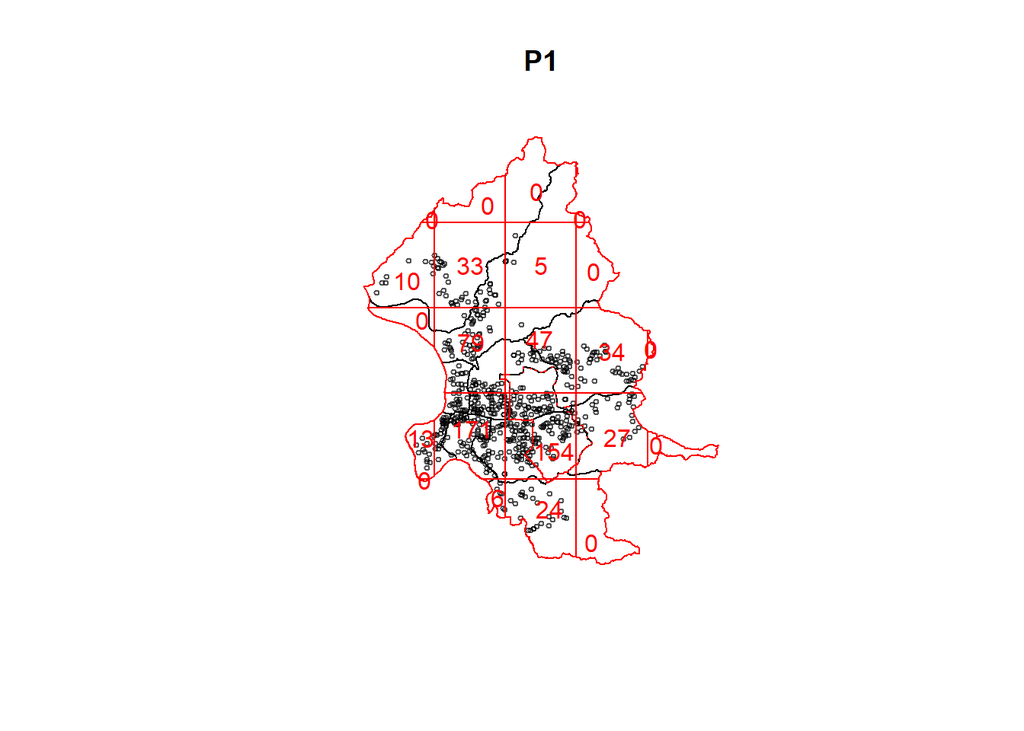

```r
plot(P1,cex=0.5)
plot(quadratcount(P1),add=TRUE,col="red")
```

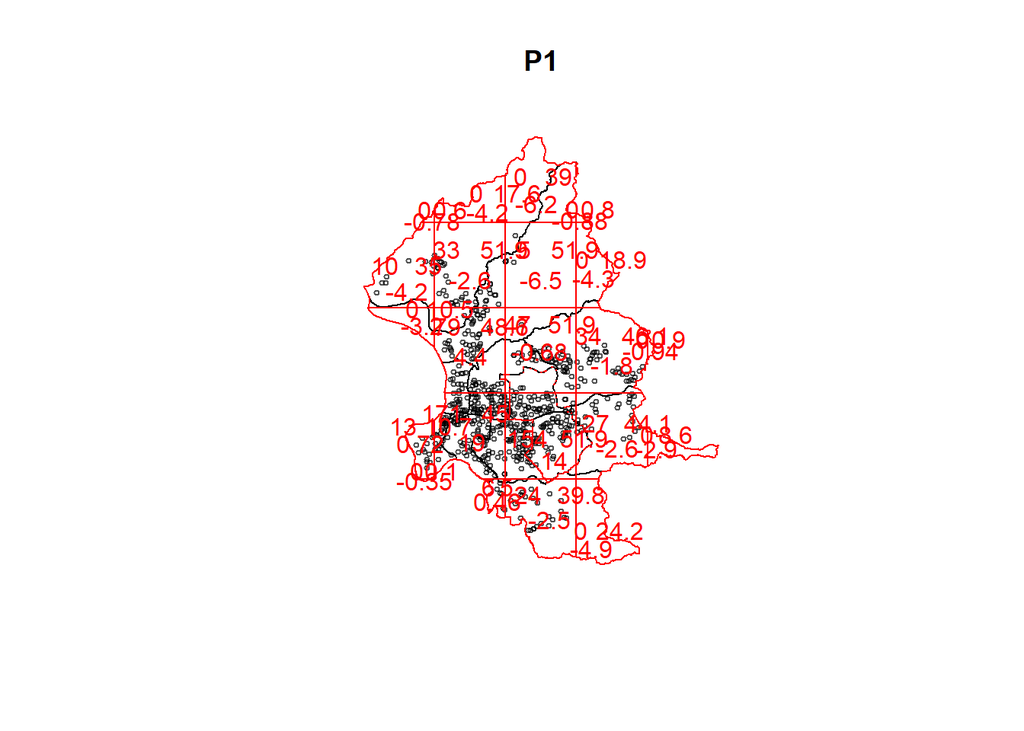

```r
#Ho:點為隨機分布
plot(P1,cex=0.5)
plot(quadrat.test(P1),add=TRUE,col="red") #左上:觀察值、右上:期望值、下方:差值
```

```r
quadrat.test(P1) #p-value 很小，拒絕 Ho
```

```
##
##  Chi-squared test of CSR using quadrat counts
##  Pearson X2 statistic
##
## data:  P1
## X2 = 777.86, df = 21, p-value < 2.2e-16
## alternative hypothesis: two.sided
##
## Quadrats: 22 tiles (irregular windows)
```

### 核密度估計(kernel density estimation, KDE)

概念:每處都有密度值，不是只有事件點的地方有密度。可以將離散點資料轉為有群聚趨勢的連續表面。

方法:在圖上畫上均勻方格，以其中一個網格為中心，選定一個半徑，計算涵蓋圓內的密度，累加密度，重複直到所有網格都計算過。

問題:帶寬的選擇

`density(x,sigma)`

#### example:spatstat的資料集(bei)

```r
density(bei)
```

```
## real-valued pixel image
## 128 x 128 pixel array (ny, nx)
## enclosing rectangle: [0, 1000] x [0, 500] metres
```

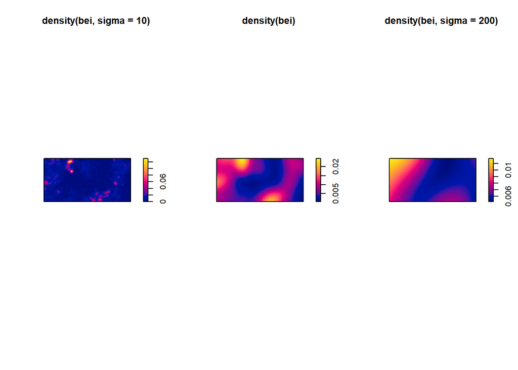

```r
par(mfrow=c(1,3))
plot(density(bei,sigma = 10))
plot(density(bei))
plot(density(bei,sigma = 200))
```

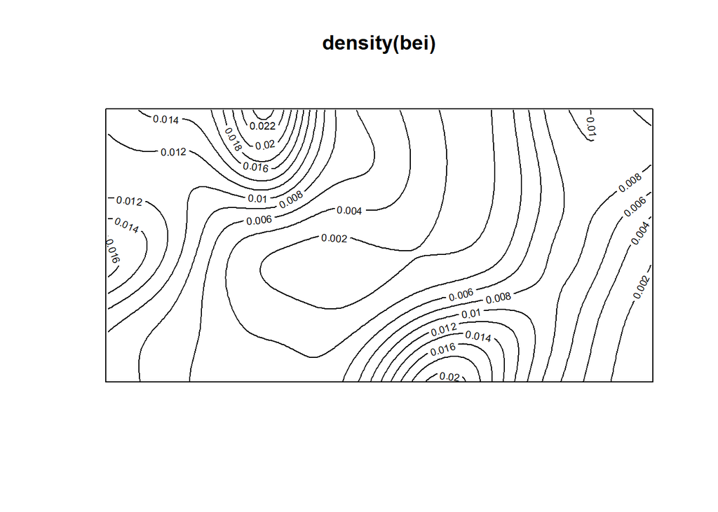

```r
contour(density(bei))
```

#### example:台北市711分布

```r
density(P1)
```

```
## real-valued pixel image
## 128 x 128 pixel array (ny, nx)
## enclosing rectangle: [121.46, 121.67] x [24.96, 25.21] units
```

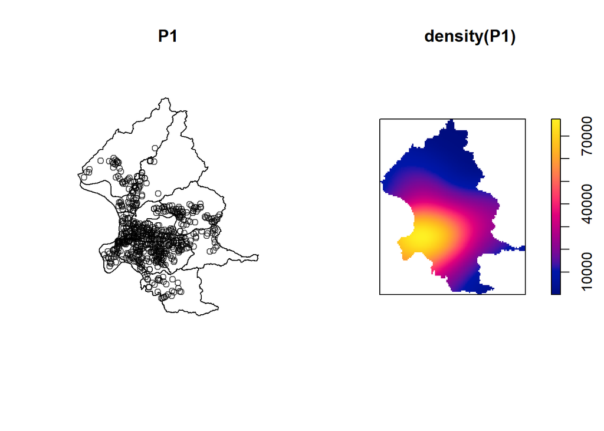

```r
par(mfrow=c(1,2))
plot(P1)
plot(density(P1))
```

### G函數

`Gest()`基於**距離**計算最鄰近距離的累積函數，分辨是否為完全隨機分布(Complete Spatial Randomness, CSR)

#### example:spatstat的資料集(cells,japanesepines,redwood)

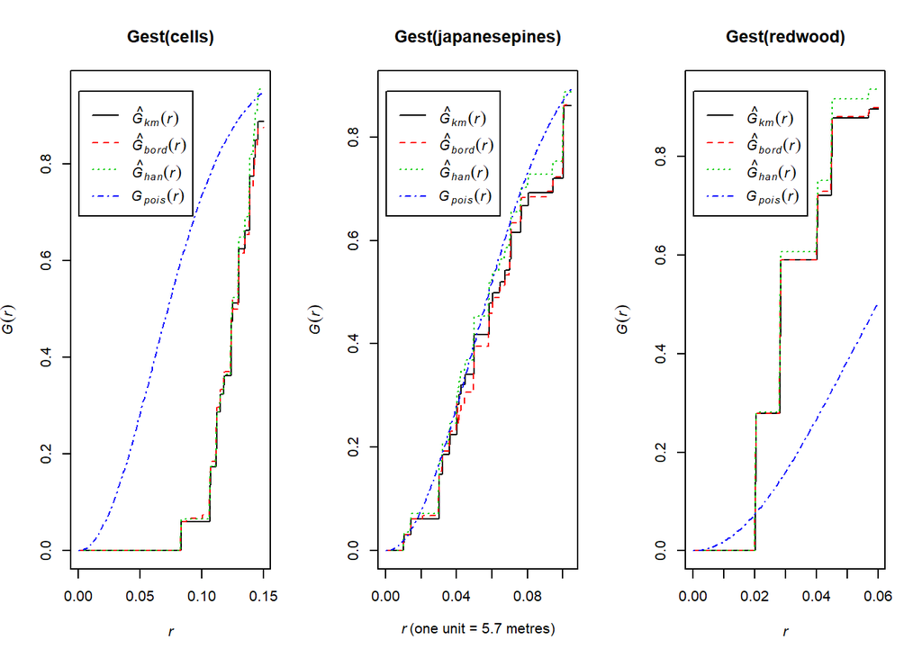

```r
#藍線為poisson,
par(mfrow=c(1,3))
plot(Gest(cells)) #G函數緩慢上升，則為均勻分布
plot(Gest(japanesepines))#和藍線重疊，則為隨機分布
plot(Gest(redwood))#G函數快速上升，則為聚集分布
```

#### example:台北市711分布

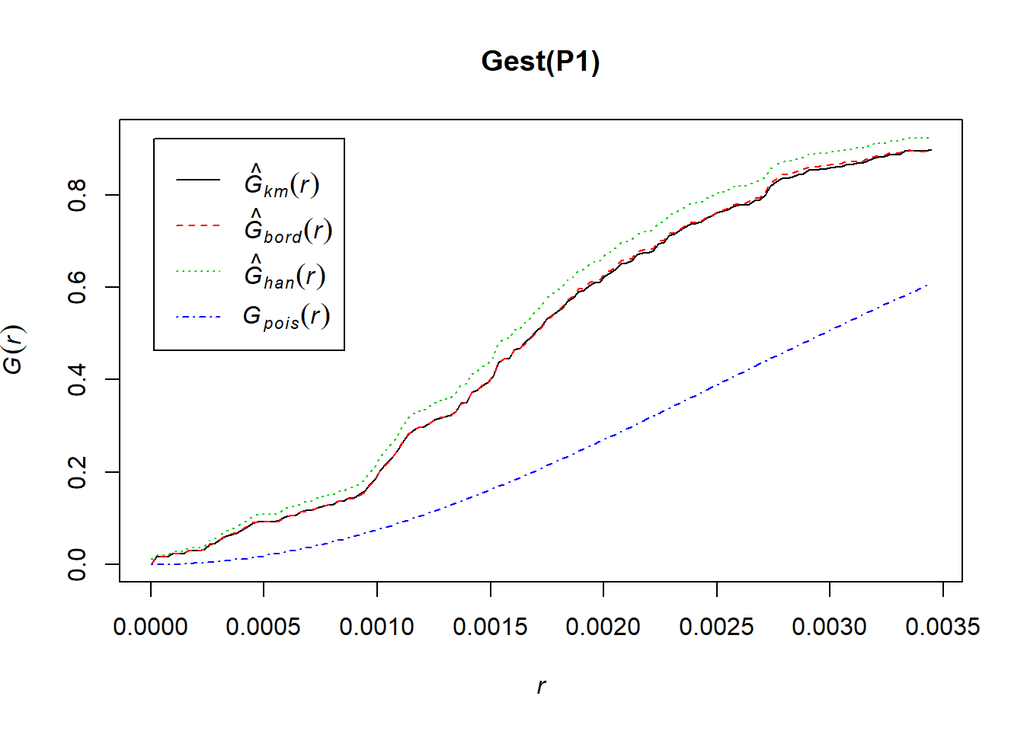

```r
plot(Gest(P1)) #台北市711分布為聚集分布
```

## reference

- [Spatstat Quick Reference guide](http://spatstat.org/resources/spatstatQuickref.pdf)
- [Package ‘spatstat’](http://spatstat.org/resources/spatstatManual.pdf)
- [Analysing spatial point patterns in R](https://research.csiro.au/software/wp-content/uploads/sites/6/2015/02/Rspatialcourse_CMIS_PDF-Standard.pdf)